# Gustavo Diaz – crim_gov_mpsa24

## Criminal Governance in Unexpected Contexts

**Lucía Tiscornia**  
University College Dublin  
lucia.tiscornia@ucd.ie

**Ines Fynn**  
Universidad Católica del Uruguay ines.fynn@ucu.edu.uy

**Verónica Pérez Bentancur**  
Universidad de la República veronica.perez@cienciassociales.edu.uy

**Gustavo Diaz**  
McMaster University  
diazg2@mcmaster.ca

Slides and paper: [talks.gustavodiaz.org](https://talks.gustavodiaz.org/)

## Question

How does criminal governance work when **state presence/capacity** is **high**?

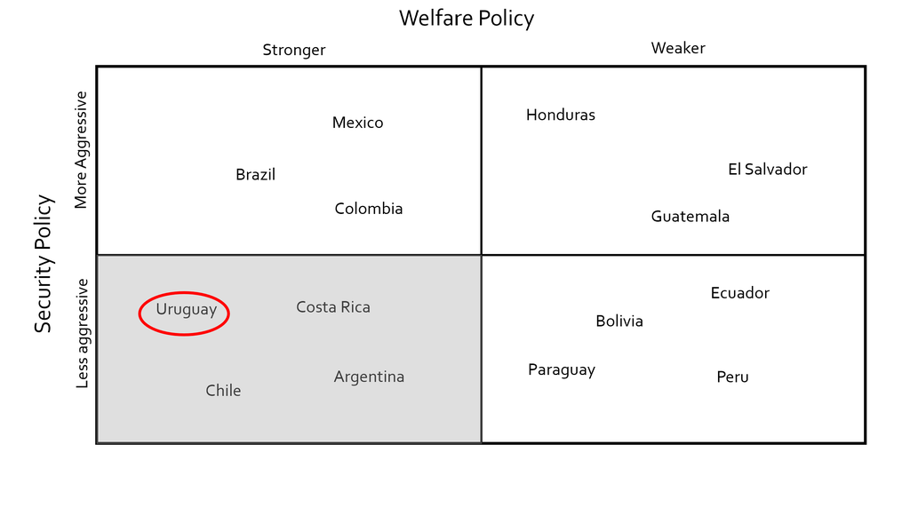

## Criminal governance

See [Arias (2017)](https://doi.org/10.1017/9781316650073), [Lessing (2021)](https://doi.org/10.1017/S1537592720001243), [Trejo and Ley (2021)](https://doi.org/10.1017/9781108894807)

## Criminal governance

Ability

See [Arias (2017)](https://doi.org/10.1017/9781316650073), [Lessing (2021)](https://doi.org/10.1017/S1537592720001243), [Trejo and Ley (2021)](https://doi.org/10.1017/9781108894807)

## Criminal governance

Ability to **control a community’s behavior**

See [Arias (2017)](https://doi.org/10.1017/9781316650073), [Lessing (2021)](https://doi.org/10.1017/S1537592720001243), [Trejo and Ley (2021)](https://doi.org/10.1017/9781108894807)

## Criminal governance

Ability to **control a community’s behavior** with the **goal of profiting from illicit markets**

See [Arias (2017)](https://doi.org/10.1017/9781316650073), [Lessing (2021)](https://doi.org/10.1017/S1537592720001243), [Trejo and Ley (2021)](https://doi.org/10.1017/9781108894807)

## Criminal governance

Ability to **control a community’s behavior** with the **goal of profiting from illicit markets**; manifest in **political**, **economic**, and **social** spheres.

Mechanisms of control:

1. **Violent:** Threats, direct violence, extortion
2. **Nonviolent:** Jobs, payment of bills, basic goods provision

See [Arias (2017)](https://doi.org/10.1017/9781316650073), [Lessing (2021)](https://doi.org/10.1017/S1537592720001243), [Trejo and Ley (2021)](https://doi.org/10.1017/9781108894807)

## Our theory

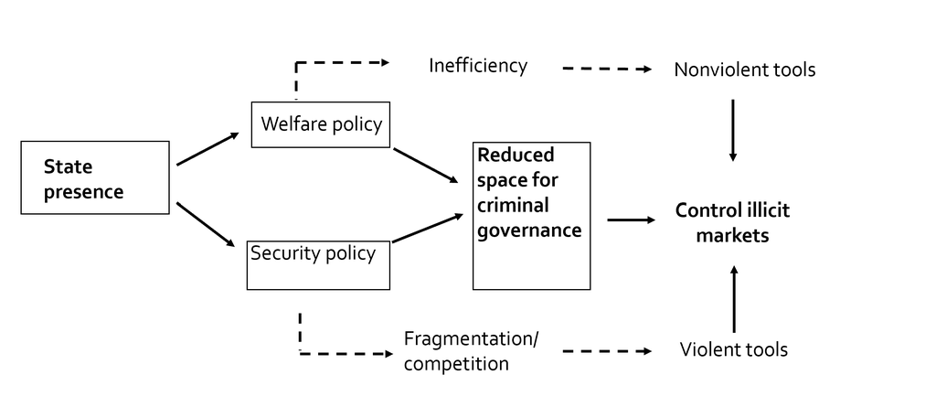

## Research Design

### Case selection: Montevideo, Uruguay

- Low violence and crime
- Extensive social protection
- **Crucial least likely case**

## Research Design

### Fieldwork (2021-2022)

- 66 in depth interviews
- Review of press and documents (2012-2022)
- **Criminal governance is a sensitive topic**
- **Affected populations are hidden**

## Research Design

### Online survey (2022)

- **Estimate prevalence of criminal governance actions**
- N = 2,688
- Direct questions
- Network scale-up questions (NSUM)

## Survey: Direct question

**During the last six months, in your neighborhood, have you seen criminal organizations…**

#### Violent

- Threaten neighbors
- Evict neighbors

#### Nonviolent

- Make donations to neighbors
- Offer jobs to neighbors

## Survey: NSUM questions

**How many X do you know,**

## Survey: NSUM questions

**How many X do you know, who also know you,**

## Survey: NSUM questions

**How many X do you know, who also know you, with whom you have interacted in the last year**

## Survey: NSUM questions

**How many X do you know, who also know you, with whom you have interacted in the last year in person, by phone, or any other channel?**

From *Las Piedras*  
Male 25-29  
Police officers  
University students  
Had a kid last year  
Passed away last year  
Married last year  
Female 45-49

Public employees  
Welfare card holders  
Registered with party  
With kids in public school  
Did not vote in last election  
Currently in jail  
Recently unemployed  
*[CRIMINAL GOVERNANCE ACTION]*

## Survey: Results

[figure not shown]

Vertical lines are 95% CI, horizontal ticks are 84% CI

## Survey: Results

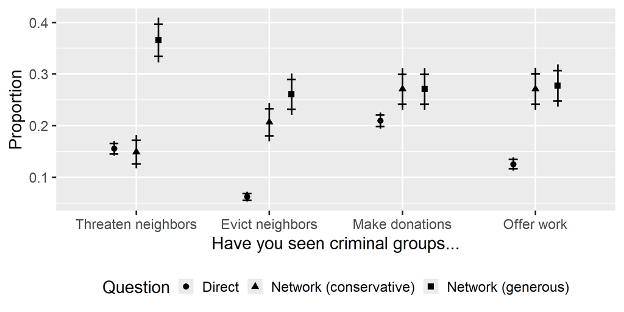

Vertical lines are 95% CI, horizontal ticks are 84% CI

## What else?

- **Survey:** Similar prevalence in low/high income neighborhoods
- **Survey:** Constrained space for criminal governance
- **Interviews:** Limited attempts at social/political control

## Conclusion

### Findings

**Learn more:** [talks.gustavodiaz.org](https://talks.gustavodiaz.org/)

## Conclusion

### Implications

- Current explanations may be biased towards cases with more aggressive security policy
- Rethink theoretical scope conditions

**Learn more:** [talks.gustavodiaz.org](https://talks.gustavodiaz.org/)